# -Analysis of Olymoic Games for sponsor-

## Objective of the Proposed Research:

### The purpose of this report is to find good athletes for the sponsors in athletics. The report will research four different aspects of data, such as region, Age, Weight, and Height. Before the investigation, I have assumed that the four aspects are related to the number of the medals. The first one is the nation. I will explore which nation has numerous medals in history. The influence of country to an athlete may be better training, policy or the environment. Especially, the war in history may cause some countries to miss the Olympic games. So, I will also compare with the data after 2004. Next, I will show the relationship between age and athletes. Age may be a contributing factor to the change of the athlete's physical status, thus affect his/her ability to win sports games. Additionally, I will also consider the physical data of athletes. I believe that their height and weight play a key role in their performance of games. In conclusion, I will integrate the data from those different aspects and find the character of good players that can help sponsor to choose good athletes for athletics.

## 1. Preparation

### -Read the data

```r
athleteEvent <- read.csv("~/Downloads/120-years-of-olympic-history-athletes-and-results/athlete_events.csv")
```

```r
nocRegion <- read.csv("~/Downloads/120-years-of-olympic-history-athletes-and-results/noc_regions.csv")
```

### -Import library we need for the function

```r
library(tidyverse)
```

### -Union two different data "athleteEvent"and "nocRegion" to "oly" file and check it

```r
oly <- athleteEvent %>% inner_join(nocRegion, by = "NOC")
head(oly)
```

| ID | Name | Sex | Age | Height | Weight | Team | NOC | Games | Year | Season | City | Sport | Event | Medal | region | notes |
| --- | --- | --- | --- | --- | --- | --- | --- | --- | --- | --- | --- | --- | --- | --- | --- | --- |
| 1 | A Dijiang | M | 24 | 180 | 80 | China | CHN | 1992 Summer | 1992 | Summer | Barcelona | Basketball | Basketball Men's Basketball | NA | China |  |
| 2 | A Lamusi | M | 23 | 170 | 60 | China | CHN | 2012 Summer | 2012 | Summer | London | Judo | Judo Men's Extra-Lightweight | NA | China |  |
| 3 | Gunnar Nielsen Aaby | M | 24 | NA | NA | Denmark | DEN | 1920 Summer | 1920 | Summer | Antwerpen | Football | Football Men's Football | NA | Denmark |  |
| 4 | Edgar Lindenau Aabye | M | 34 | NA | NA | Denmark/Sweden | DEN | 1900 Summer | 1900 | Summer | Paris | Tug-Of-War | Tug-Of-War Men's Tug-Of-War | Gold | Denmark |  |
| 5 | Christine Jacoba Aaftink | F | 21 | 185 | 82 | Netherlands | NED | 1988 Winter | 1988 | Winter | Calgary | Speed Skating | Speed Skating Women's 500 metres | NA | Netherlands |  |
| 5 | Christine Jacoba Aaftink | F | 21 | 185 | 82 | Netherlands | NED | 1988 Winter | 1988 | Winter | Calgary | Speed Skating | Speed Skating Women's 1,000 metres | NA | Netherlands |  |

### -Check the structure of data. I need to change ID to be factor type becasue one athlete may have participated many different matches.

```r
str(oly)
```

```
'data.frame':	270767 obs. of  17 variables:
 $ ID    : int  1 2 3 4 5 5 5 5 5 5 ...
 $ Name  : Factor w/ 134732 levels "  Gabrielle Marie \"Gabby\" Adcock (White-)",..: 8 9 44318 29412 21469 21469 21469 21469 21469 21469 ...
 $ Sex   : Factor w/ 2 levels "F","M": 2 2 2 2 1 1 1 1 1 1 ...
 $ Age   : int  24 23 24 34 21 21 25 25 27 27 ...
 $ Height: int  180 170 NA NA 185 185 185 185 185 185 ...
 $ Weight: num  80 60 NA NA 82 82 82 82 82 82 ...
 $ Team  : Factor w/ 1184 levels "30. Februar",..: 199 199 273 278 705 705 705 705 705 705 ...
 $ NOC   : chr  "CHN" "CHN" "DEN" "DEN" ...
 $ Games : Factor w/ 51 levels "1896 Summer",..: 38 49 7 2 37 37 39 39 40 40 ...
 $ Year  : int  1992 2012 1920 1900 1988 1988 1992 1992 1994 1994 ...
 $ Season: Factor w/ 2 levels "Summer","Winter": 1 1 1 1 2 2 2 2 2 2 ...
 $ City  : Factor w/ 42 levels "Albertville",..: 6 18 3 27 9 9 1 1 17 17 ...
 $ Sport : Factor w/ 66 levels "Aeronautics",..: 9 33 25 62 54 54 54 54 54 54 ...
 $ Event : Factor w/ 765 levels "Aeronautics Mixed Aeronautics",..: 160 398 349 710 623 619 623 619 623 619 ...
 $ Medal : Factor w/ 3 levels "Bronze","Gold",..: NA NA NA 2 NA NA NA NA NA NA ...
 $ region: Factor w/ 206 levels "Afghanistan",..: 40 40 51 51 130 130 130 130 130 130 ...
 $ notes : Factor w/ 22 levels "","Antigua and Barbuda",..: 1 1 1 1 1 1 1 1 1 1 ...
```

```r
oly$ID <- factor(oly$ID)
```

```r
str(oly)
```

```
'data.frame':	270767 obs. of  17 variables:
 $ ID    : Factor w/ 135404 levels "1","2","3","4",..: 1 2 3 4 5 5 5 5 5 5 ...
 $ Name  : Factor w/ 134732 levels "  Gabrielle Marie \"Gabby\" Adcock (White-)",..: 8 9 44318 29412 21469 21469 21469 21469 21469 21469 ...
 $ Sex   : Factor w/ 2 levels "F","M": 2 2 2 2 1 1 1 1 1 1 ...
 $ Age   : int  24 23 24 34 21 21 25 25 27 27 ...
 $ Height: int  180 170 NA NA 185 185 185 185 185 185 ...
 $ Weight: num  80 60 NA NA 82 82 82 82 82 82 ...
 $ Team  : Factor w/ 1184 levels "30. Februar",..: 199 199 273 278 705 705 705 705 705 705 ...
 $ NOC   : chr  "CHN" "CHN" "DEN" "DEN" ...
 $ Games : Factor w/ 51 levels "1896 Summer",..: 38 49 7 2 37 37 39 39 40 40 ...
 $ Year  : int  1992 2012 1920 1900 1988 1988 1992 1992 1994 1994 ...
 $ Season: Factor w/ 2 levels "Summer","Winter": 1 1 1 1 2 2 2 2 2 2 ...
 $ City  : Factor w/ 42 levels "Albertville",..: 6 18 3 27 9 9 1 1 17 17 ...
 $ Sport : Factor w/ 66 levels "Aeronautics",..: 9 33 25 62 54 54 54 54 54 54 ...
 $ Event : Factor w/ 765 levels "Aeronautics Mixed Aeronautics",..: 160 398 349 710 623 619 623 619 623 619 ...
 $ Medal : Factor w/ 3 levels "Bronze","Gold",..: NA NA NA 2 NA NA NA NA NA NA ...
 $ region: Factor w/ 206 levels "Afghanistan",..: 40 40 51 51 130 130 130 130 130 130 ...
 $ notes : Factor w/ 22 levels "","Antigua and Barbuda",..: 1 1 1 1 1 1 1 1 1 1 ...
```

## 2. Four aspects of data in Athletics

### a. Relationship between number of medal and countries.

### List the total number of medal each country recieved in 120 years

### - Pipe operator "%>%" is allow the object on the left to pass the first argument to the function on right side.

### - The code is taking out the NA value in Medal column from oly file, then calculate the total sum of each region got.

```r
medalOfNoc <- oly %>% filter(!is.na(Medal), Sport == "Athletics") %>% group_by(region) %>% summarize(NumOfMed = n())
head(medalOfNoc[order(medalOfNoc$NumOfMed, decreasing = T), ])
```

| region | NumOfMed |
| --- | --- |
| USA | 1080 |
| Russia | 374 |
| Germany | 365 |
| UK | 338 |
| Jamaica | 156 |
| Finland | 138 |

### -Filtered out the data before 2004 because some countries cannot participate past Olmypics due to war or some issues.

```r
medalOfNoc2004 <- oly %>% filter(Year >= 2004, !is.na(Medal), Sport == "Athletics")  %>% group_by(region) %>% summarize(NumOfMed2004 = n())
head(medalOfNoc2004[order(medalOfNoc2004$NumOfMed2004, decreasing = T), ])
```

| region | NumOfMed2004 |
| --- | --- |
| USA | 158 |
| Jamaica | 82 |
| Russia | 75 |
| Kenya | 46 |
| UK | 35 |
| Ethiopia | 29 |

### -Check the number of participant of athletics after 2004

```r
ParticiOfNoc2004 <- oly %>% filter(Year >= 2004, Sport == "Athletics")  %>% group_by(region) %>% summarize(particiOfMed2004 = n())
head(ParticiOfNoc2004[order(ParticiOfNoc2004$particiOfMed2004, decreasing = T), ])
```

| region | particiOfMed2004 |
| --- | --- |
| USA | 558 |
| Russia | 347 |
| UK | 312 |
| Germany | 299 |
| Ukraine | 279 |
| Poland | 249 |

### -Look at the data above, we can see that two different period of times have the same top one country in the rank. USA have more participant in this games, so they may have more chance to win. But, Jamaica have less people but they got many medals after 2004.

## B. Relationship between number of medal and age in athletics.

### - Distribution of medal based on age, and filter out age groups which didn't have any medal. And, show 10 largest number of players with medals connect with age.

```r
medalAge <- oly %>% filter(!is.na(Medal),Sport == "Athletics") %>% group_by(Age) %>% summarize(AgeNumMed=n())
head(medalAge[order(medalAge$AgeNumMed, decreasing = T), ], n = 10)
```

| Age | AgeNumMed |
| --- | --- |
| 23 | 441 |
| 22 | 426 |
| 24 | 400 |
| 25 | 380 |
| 26 | 333 |
| 21 | 308 |
| 27 | 282 |
| 28 | 249 |
| 20 | 198 |
| 29 | 185 |

### -Consider number of medals on each age group and 10 largest number of players with medals in age group.

```r
NumAge <- oly %>% filter(Sport == "Athletics")%>% group_by(Age) %>% summarize(numAge = n())
head(NumAge[order(NumAge$numAge, decreasing = T), ], n = 10)
```

| Age | numAge |
| --- | --- |
| 23 | 3741 |
| 24 | 3597 |
| 25 | 3427 |
| 22 | 3317 |
| 26 | 3043 |
| 21 | 2860 |
| 27 | 2747 |
| 28 | 2284 |
| 20 | 2177 |
| 29 | 1795 |

### -Analyize the data above, we found the top 10 of rank of ages in both data are alomst same. It means that the players in those age group have more high rate to win the game due to the number of participants. Thus, we can speculate the relationship between age and medal is unrelated. we will have plot about it later.

## C. Relationship between number of medal and height.

### - First one show 10 largest number of medals in each Height group.

### - Second one show the number of athlete in each group.

### - I filter out the data which is has NA value in medal and height columns.

```r
heightMedal <- oly %>% filter(!is.na(Medal), !is.na(Height), Sport == "Athletics") %>% group_by(Height) %>% summarize(NumHeightMedal = n())
head(heightMedal[order(heightMedal$NumHeightMedal, decreasing = T), ], n = 10)

heightGroup <- oly %>% filter(!is.na(Height), Sport == "Athletics") %>% group_by(Height) %>% summarize(NumHeightGroup = n())
head(heightGroup[order(heightGroup$NumHeightGroup, decreasing = T), ], n = 10)
```

| Height | NumHeightMedal |
| --- | --- |
| 178 | 245 |
| 183 | 235 |
| 180 | 227 |
| 170 | 214 |
| 175 | 204 |
| 185 | 169 |
| 188 | 164 |
| 168 | 157 |
| 173 | 139 |
| 172 | 131 |

| Height | NumHeightGroup |
| --- | --- |
| 180 | 2154 |
| 178 | 1999 |
| 170 | 1923 |
| 175 | 1896 |
| 183 | 1593 |
| 168 | 1455 |
| 173 | 1270 |
| 172 | 1245 |
| 185 | 1151 |
| 176 | 1141 |

### -From the data above, in Genera, the better height for athletic is around 178(cm).

### D. Relationship between number of medal and weight.

### - First one show 10 largest number of medals in weight group.

### - Second one show the 10 largest number of participant in weight group.

### - I filtered out the data which is has NA value in medal and weight columns.

```r
weightMedal <- oly %>% filter(!is.na(Medal), !is.na(Weight), Sport == "Athletics") %>% group_by(Weight) %>% summarize(NumWeightMedal = n())
head(weightMedal[order(weightMedal$NumWeightMedal, decreasing = T), ], n = 10)

weightGroup <- oly %>% filter(!is.na(Weight), Sport == "Athletics") %>% group_by(Weight) %>% summarize(NumWeightGroup = n())
head(weightGroup[order(weightGroup$NumWeightGroup, decreasing = T), ], n = 10)
```

| Weight | NumWeightMedal |
| --- | --- |
| 70 | 149 |
| 68 | 139 |
| 64 | 135 |
| 60 | 133 |
| 75 | 133 |
| 57 | 131 |
| 58 | 115 |
| 62 | 114 |
| 80 | 114 |
| 66 | 111 |

| Weight | NumWeightGroup |
| --- | --- |
| 70 | 1532 |
| 60 | 1436 |
| 65 | 1232 |
| 68 | 1186 |
| 75 | 1162 |
| 58 | 1115 |
| 62 | 1102 |
| 64 | 1098 |
| 63 | 1031 |
| 72 | 947 |

### - In here, we can see the top 10 of weight for athletics. compare with two data, the best choise is around 68kg.

## 3. Five columns I chose

```r
head(oly [, c("Height","Weight","Year","region","Medal")], n= 0)
```

| Height | Weight | Year | region | Medal |
| --- | --- | --- | --- | --- |

### - I chose this five colums becasue the union of those four can allow Kaggle's to find who has more high possibility to win the next matches. Read the data below, Jamaica have won many gold recently after 2000 year. So, in this five columns, it allows you to analyze what kind of medal this person got and when.

## 4. Data of five columns

### -According to the results of data above, I used the function to find the data which is region == "Jamaica"

```r
colChoose1 <- filter(oly, !is.na(Medal), Sport == "Athletics", region =="Jamaica", Year > 2000)
head(select (colChoose1, Height, Weight, Medal, region, Year), n = 10)
summary(colChoose1)
```

| Height | Weight | Medal | region | Year |
| --- | --- | --- | --- | --- |
| 178 | NA | Silver | Jamaica | 2016 |
| 183 | 77 | Gold | Jamaica | 2016 |
| 170 | 64 | Gold | Jamaica | 2004 |
| 193 | 84 | Gold | Jamaica | 2012 |
| 193 | 84 | Gold | Jamaica | 2016 |
| 180 | 80 | Silver | Jamaica | 2012 |
| 180 | 80 | Silver | Jamaica | 2012 |
| 180 | 80 | Gold | Jamaica | 2012 |
| 180 | 80 | Gold | Jamaica | 2016 |
| 196 | 95 | Gold | Jamaica | 2008 |

```
       ID                                  Name    Sex         Age
 13029  : 8   Usain St. Leo Bolt             : 8   F:54   Min.   :19.00
 17755  : 7   Veronica Angella Campbell-Brown: 7   M:28   1st Qu.:22.00
 36870  : 6   Shelly-Ann Fraser-Pryce        : 6          Median :24.50
 12086  : 4   Novlene Hilaire Williams-Mills : 4          Mean   :25.09
 130707 : 4   Yohan Blake                    : 4          3rd Qu.:27.75
 110897 : 3   Elaine Thompson                : 3          Max.   :35.00
 (Other):50   (Other)                        :50
     Height          Weight                         Team        NOC
 Min.   :160.0   Min.   :51.00   Jamaica              :82   Length:82
 1st Qu.:168.0   1st Qu.:57.00   30. Februar          : 0   Class :character
 Median :170.0   Median :61.00   A North American Team: 0   Mode  :character
 Mean   :174.2   Mean   :67.51   Acipactli            : 0
 3rd Qu.:180.0   3rd Qu.:78.00   Acturus              : 0
 Max.   :196.0   Max.   :95.00   Afghanistan          : 0
 NA's   :1       NA's   :3       (Other)              : 0
         Games         Year         Season               City
 2016 Summer:30   Min.   :2004   Summer:82   Rio de Janeiro:30
 2012 Summer:25   1st Qu.:2008   Winter: 0   London        :25
 2008 Summer:14   Median :2012               Beijing       :14
 2004 Summer:13   Mean   :2012               Athina        :13
 1896 Summer: 0   3rd Qu.:2016               Albertville   : 0
 1900 Summer: 0   Max.   :2016               Amsterdam     : 0
 (Other)    : 0                              (Other)       : 0
              Sport                                       Event       Medal
 Athletics       :82   Athletics Women's 4 x 400 metres Relay:21   Bronze:22
 Aeronautics     : 0   Athletics Women's 4 x 100 metres Relay:17   Gold  :30
 Alpine Skiing   : 0   Athletics Men's 4 x 100 metres Relay  :11   Silver:30
 Alpinism        : 0   Athletics Women's 100 metres          : 8
 Archery         : 0   Athletics Men's 200 metres            : 5
 Art Competitions: 0   Athletics Men's 4 x 400 metres Relay  : 5
 (Other)         : 0   (Other)                               :15
            region                   notes
 Jamaica       :82                      :82
 Afghanistan   : 0   Antigua and Barbuda: 0
 Albania       : 0   Australasia        : 0
 Algeria       : 0   Bohemia            : 0
 American Samoa: 0   Crete              : 0
 Andorra       : 0   Hong Kong          : 0
 (Other)       : 0   (Other)            : 0
```

### In this data, we can see Jamaica have much good recording of games. we can make sure this country is our target. then, analyzing the weight and height, we could speculate the person who is around 180cm or 68kg in Jamaica is a good choise.

## 6.Plot of population and the number of medalist in each age group

### - Use the function "qplot" to draw the plots. I use "Age" to be X and "numAge(number of age)" to be Y, and data from oly file.

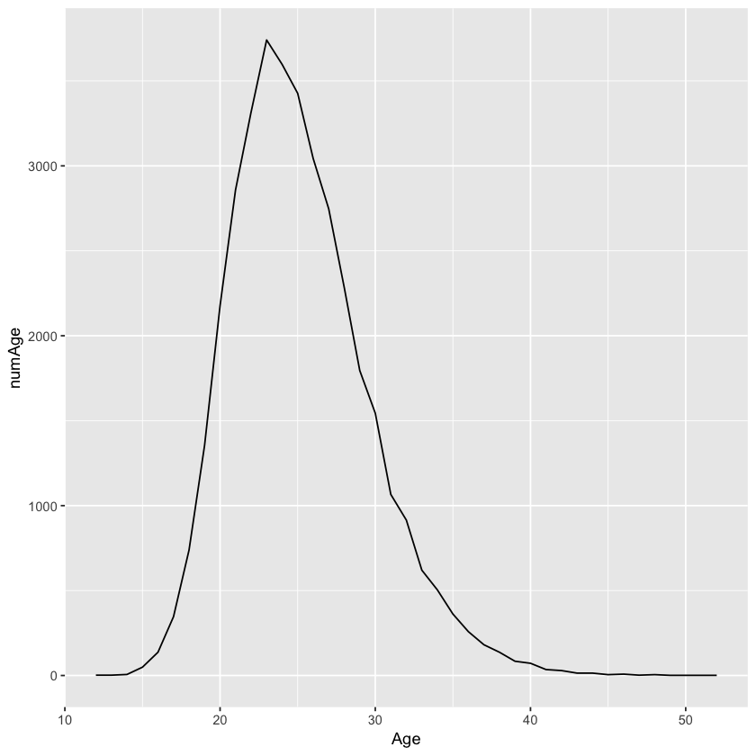

```r
qplot(Age, numAge, data = NumAge,
geom = c("line"))
```

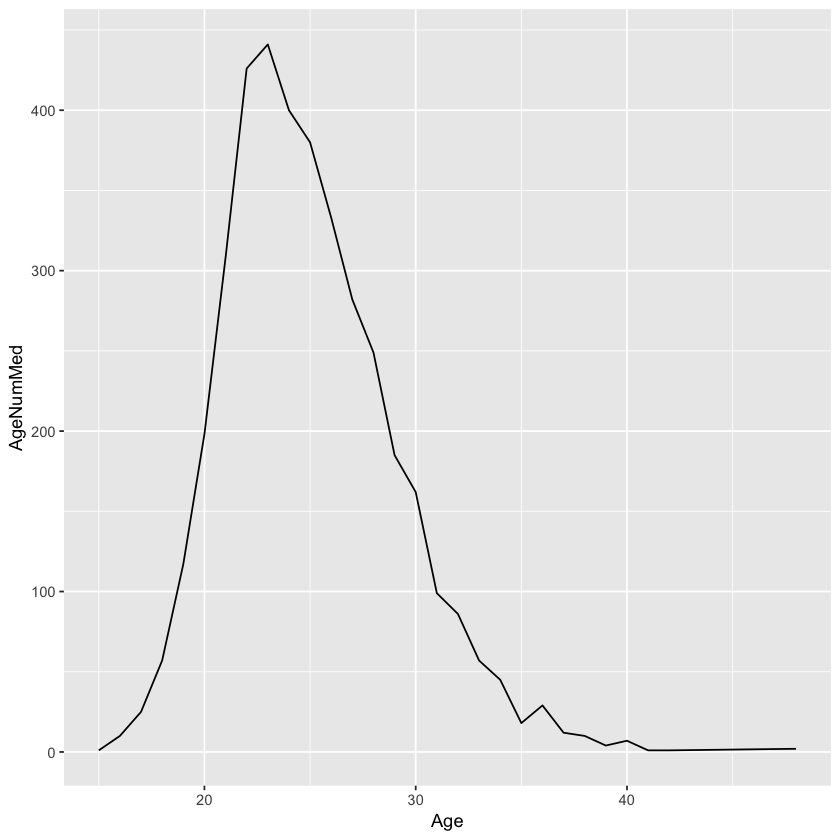

```r
qplot(Age, AgeNumMed, data = medalAge,
     geom = c("line"))
```

## 9.Extra data analytics

### -a.Age

```r
head(sort(NumAge$Age, decreasing = F), 15)
```

1. 12

2. 13

3. 14

4. 15

5. 16

6. 17

7. 18

8. 19

9. 20

10. 21

11. 22

12. 23

13. 24

14. 25

15. 26

```r
head(sort(NumAge$Age, decreasing = T), 15)
```

1. 52

2. 50

3. 49

4. 48

5. 47

6. 46

7. 45

8. 44

9. 43

10. 42

11. 41

12. 40

13. 39

14. 38

15. 37

### -After I used the function to sort out the data of age, the interesting is that the youngest participant in athletics is only 12 years old. I am suprise about it. and also the oldest player is 52 already. That two are over my imagination.

### b.Height

```r
head(sort(heightMedal$Height, decreasing = T), 15)
```

1. 207

2. 204

3. 203

4. 202

5. 201

6. 200

7. 199

8. 198

9. 197

10. 196

11. 195

12. 194

13. 193

14. 192

15. 191

```r
head(sort(heightMedal$Height, decreasing = F), 15)
```

1. 150

2. 152

3. 153

4. 154

5. 155

6. 156

7. 157

8. 158

9. 159

10. 160

11. 161

12. 162

13. 163

14. 164

15. 165

### -The hightest player who has medal in athletics in Olympic Games was 207 and the lowest player is 150.